# STAT694 Project Presentation

12/11/2020

## Project Title

A Research on the relationship between the seriousness of Natural Disaster and the Sentiment of Twitter Text - A COVID-19 Pandemic Case Study

## Project Objectives

- Study the social media’s text data structures
- Apply basic Natural Language Processing Technique to perform sentiment analysis on tweet text
- Study if there is association between the level of natural disaster and sentiment of the text

## Programming Languages

- Python to connect to Twitter API and obtain raw tweet text
- R to data wrangling, presentation and statistical analysis

## Cities to Study

- San Francisco, CA
- Los Angeles, CA
- Chicago, IL
- Miami, FL
- New York, NY

Significant population in the country with higher COVID-19 Confirmed Rate

## COVID-19 Data

- San Francisco: I used San Francisco County, CA data
- Los Angeles, I used Los Angeles County, CA data.
- Chicago, I used Cook County, Illinois data.
- Miami, I used Miami-Dade County, Florida data.
- New York, I used the combined 5 counties data, and the counties are:
  - Brooklyn, NY
  - Bronx. NY
  - Manhattan, NY
  - Queens, NY
  - Staten Island, NY

## Steps:

- Connect to Twitter API using Python and gather data
- Load original csv file to R for data wrangling
  - Remove Hyperlinks, Punctuation, Hashtags etc
  - Remove stop words
- Use packages in R for Data Visualization and Summary Statistics

## Basic Statistics 1

Summary Statistics of Tweets

| Location | Tweet Count | Tweet Ratio | Tweet Mean Char | Tweet Char Usage | Population | Population Ratio |
| --- | --- | --- | --- | --- | --- | --- |
| Chicago | 4209 | 0.1840644 | 158 | 0.5642857 | 2830144 | 0.1771438 |
| Los Angeles | 5873 | 0.2568330 | 158 | 0.5642857 | 3911500 | 0.2448278 |
| Miami | 1390 | 0.0607863 | 146 | 0.5214286 | 386740 | 0.0242068 |
| New York | 8927 | 0.3903879 | 155 | 0.5535714 | 8124427 | 0.5085225 |
| San Francisco | 2468 | 0.1079285 | 162 | 0.5785714 | 723724 | 0.0452992 |

## Basic Statistics 2

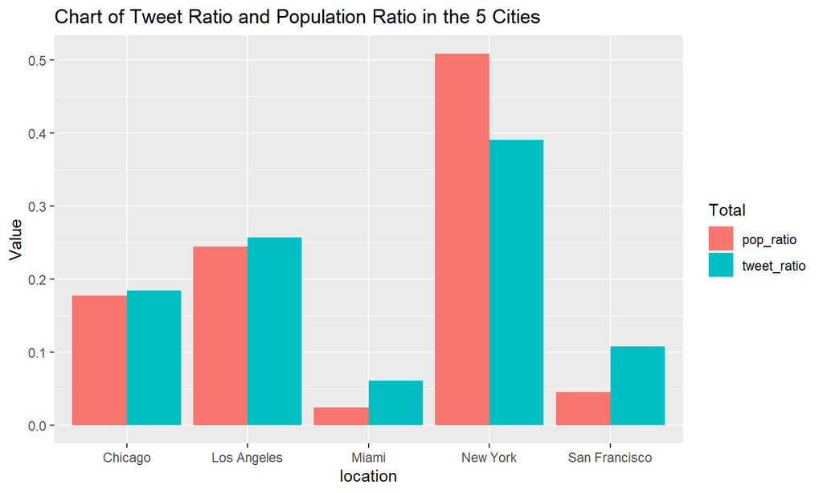

## Sample Data Frame Structure

Oct 5 2020 Tweet with Location & Text Filtered

| Location | Tweet Text | Tweet Created Time |
| --- | --- | --- |
| Los Angeles | trump has been the biggest source of covid misinformation study finds | 2020-10-05 |
| Miami | i just got off the phone with coach bowden told me hes feeling okay he tested positive for covid while at the hospital last week he doesnt know how he contracted it told me hes getting tested again to… | 2020-10-05 |
| New York | no reports of receiving either hydroxychloroquine or chloroquine since being diagnosed with covid | 2020-10-05 |
| San Francisco | president trump s treatment regimen for covid suggests he s either being overtreated or is sicker than is being let on based on interviews with physicians over the past days | 2020-10-05 |
| Chicago | my wife doesn t believe kayleigh mcenany or any of the trump staff have covid she thinks they are just saying it to make it look like trump really must have it when he really doesn t i m inclined to a… | 2020-10-05 |
| Chicago | if senior government officials do not announce their diagnoses of covid immediately they put other senior officials at risk that s why im calling on congress to establish clear standards for the publi… | 2020-10-05 |

## More in-depth Statistics:

Top 10 Most Frequent Word Appeared

| Word | Count |
| --- | --- |
| covid | 18886 |
| trump | 6023 |
| people | 2479 |
| president | 2191 |
| tested | 2145 |
| positive | 1888 |
| pandemic | 1845 |
| amp | 1837 |
| americans | 1458 |
| health | 1422 |

[figure not shown]

## Results

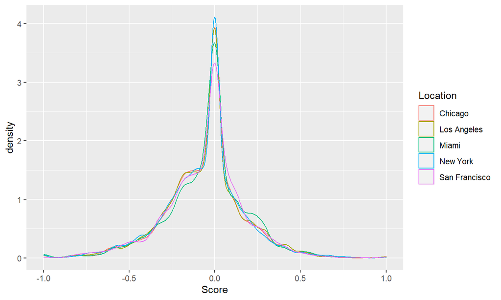

## Result 2

Summary Stat of 5 Cities

| Location | n | Mean | SD | Variance |
| --- | --- | --- | --- | --- |
| Chicago | 4201 | -0.0617642 | 0.2505062 | 0.0627533 |
| Los Angeles | 5862 | -0.0616610 | 0.2520286 | 0.0635184 |
| Miami | 1388 | -0.0471243 | 0.2395445 | 0.0573816 |
| New York | 8904 | -0.0652148 | 0.2540056 | 0.0645188 |
| San Francisco | 2464 | -0.0575869 | 0.2419290 | 0.0585296 |

[figure not shown]

## Comments:

- Since data for five cities is not normally distributed. We can not use traditional ANOVA. -(P-value > 0.05 in Shapiro-Wilk normality test)
- I use Wilcoxon rank sum test to test the difference between 5 cities
  - Most of the cities doesn’t have significance difference.
  - i.e. P-value > 0.05

## Further Work

- Study a long period (Months)
- Collect more data per day
  - Now limited by Twitter free developer account
- Break tweets into parts of sentence, avoid word by word analysis.
- Apply Machine Learning Algorithm like SVM for
  - Classification
  - Regression on prediction of sentiment score

12/3/2020

## Project Title

A Research on the relationship between the seriousness of Natural Disaster and the Sentiment of Twitter Text - A COVID-19 Pandemic Case Study

## Project Objectives

- Study the social media’s text data structures
- Apply basic Natural Language Processing Technique to perform sentiment analysis on tweet text
- Study if there is association between the level of natural disaster and sentiment of the text

## Programming Languages

- Python to connect to Twitter API and obtain raw tweet text
- R to data wrangling, presentation and statistical analysis

## Cities to Study

- San Francisco, CA
- Los Angeles, CA
- Chicago, IL
- Miami, FL
- New York, NY

Significant population in the country with higher COVID-19 Confirmed Rate

## COVID-19 Data

- San Francisco: I used San Francisco County, CA data
- Los Angeles, I used Los Angeles County, CA data.
- Chicago, I used Cook County, Illinois data.
- Miami, I used Miami-Dade County, Florida data.
- New York, I used the combined 5 counties data, and the counties are:
  - Brooklyn, NY
  - Bronx. NY
  - Manhattan, NY
  - Queens, NY
  - Staten Island, NY

## Steps:

- Connect to Twitter API using Python and gather data
- Load original csv file to R for data wrangling
  - Remove Hyperlinks, Punctuation, Hashtags etc
  - Remove stop words
- Use packages in R for Data Visualization and Summary Statistics

## Basic Statistics 1

Summary Statistics of Tweets

| Location | Tweet Count | Tweet Ratio | Tweet Mean Char | Tweet Char Usage | Population | Population Ratio |
| --- | --- | --- | --- | --- | --- | --- |
| Chicago | 4209 | 0.1840644 | 158 | 0.5642857 | 2830144 | 0.1771438 |
| Los Angeles | 5873 | 0.2568330 | 158 | 0.5642857 | 3911500 | 0.2448278 |
| Miami | 1390 | 0.0607863 | 146 | 0.5214286 | 386740 | 0.0242068 |
| New York | 8927 | 0.3903879 | 155 | 0.5535714 | 8124427 | 0.5085225 |
| San Francisco | 2468 | 0.1079285 | 162 | 0.5785714 | 723724 | 0.0452992 |

## Basic Statistics 2

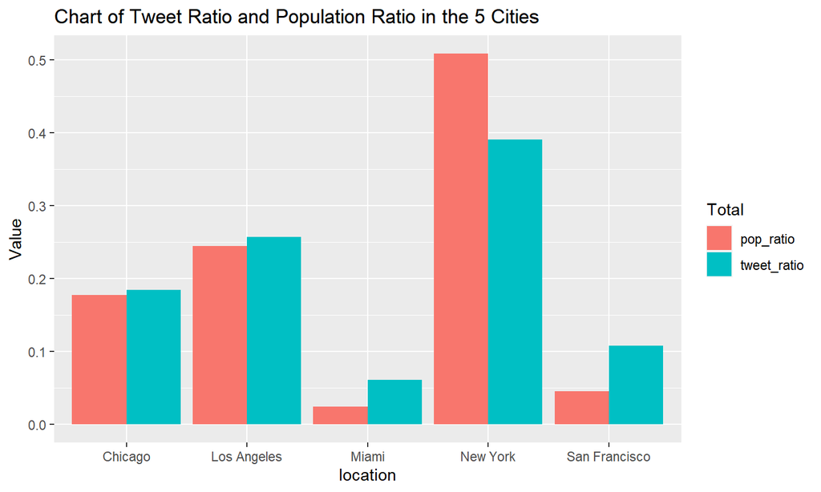

## Sample Data Frame Structure

Oct 5 2020 Tweet with Location & Text Filtered

| Location | Tweet Text | Tweet Created Time |
| --- | --- | --- |
| Los Angeles | trump has been the biggest source of covid misinformation study finds | 2020-10-05 |
| Miami | i just got off the phone with coach bowden told me hes feeling okay he tested positive for covid while at the hospital last week he doesnt know how he contracted it told me hes getting tested again to… | 2020-10-05 |
| New York | no reports of receiving either hydroxychloroquine or chloroquine since being diagnosed with covid | 2020-10-05 |
| San Francisco | president trump s treatment regimen for covid suggests he s either being overtreated or is sicker than is being let on based on interviews with physicians over the past days | 2020-10-05 |
| Chicago | my wife doesn t believe kayleigh mcenany or any of the trump staff have covid she thinks they are just saying it to make it look like trump really must have it when he really doesn t i m inclined to a… | 2020-10-05 |
| Chicago | if senior government officials do not announce their diagnoses of covid immediately they put other senior officials at risk that s why im calling on congress to establish clear standards for the publi… | 2020-10-05 |

## More in-depth Statistics:

Top 10 Most Frequent Word Appeared

| Word | Count |
| --- | --- |
| covid | 18886 |
| trump | 6023 |
| people | 2479 |
| president | 2191 |
| tested | 2145 |
| positive | 1888 |
| pandemic | 1845 |
| amp | 1837 |
| americans | 1458 |
| health | 1422 |

## Results

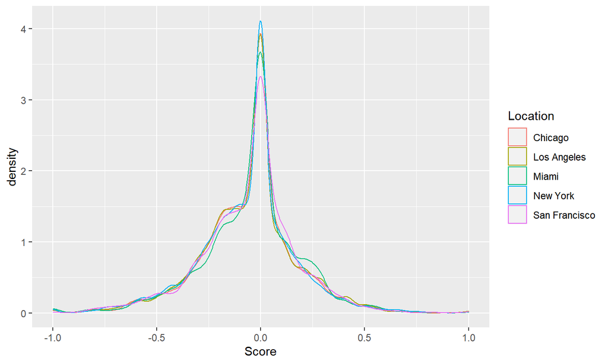

## Result 2

Summary Stat of 5 Cities

| Location | n | Mean | SD | Variance |
| --- | --- | --- | --- | --- |
| Chicago | 4201 | -0.0617642 | 0.2505062 | 0.0627533 |
| Los Angeles | 5862 | -0.0616610 | 0.2520286 | 0.0635184 |
| Miami | 1388 | -0.0471243 | 0.2395445 | 0.0573816 |
| New York | 8904 | -0.0652148 | 0.2540056 | 0.0645188 |
| San Francisco | 2464 | -0.0575869 | 0.2419290 | 0.0585296 |

[figure not shown]

[figure not shown]

## Comments:

- Since data for five citiesis not normally distributed. We can not use traditional ANOVA. -(P-value > 0.05 in Shapiro-Wilk normality test)
- I use Wilcoxon rank sum test to test the difference between 5 cities
  - Most of the cities doesn’t have significance difference.
  - i.e. P-value > 0.05

## Further Work

- Study a long period (Months)
- Collect more data per day
  - Now limited by Twitter free developer account
- Break tweets into parts of sentence, avoid word by word analysis.
- Apply Machine Learning Algorithm like SVM for
  - Classification
  - Regression on prediction of sentiment score